# Proyecto 2 “House Prices: Advanced Regression Techniques”

## 11. Modelo univariado de regresión lineal para predecir el precio de las casas

Para este modelo se seleccionó a la variable OverallQual que representa la calidad general de las casas

```
Mean Squared Error: 0.38
R squared: 0.68
```

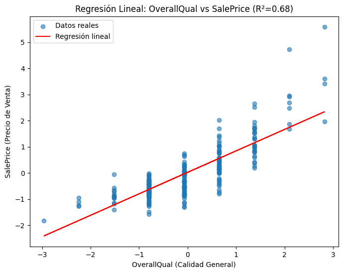

```
                            OLS Regression Results
==============================================================================
Dep. Variable:                      y   R-squared:                       0.632
Model:                            OLS   Adj. R-squared:                  0.631
Method:                 Least Squares   F-statistic:                     1598.
Date:                Sun, 02 Mar 2025   Prob (F-statistic):          2.45e-204
Time:                        21:22:27   Log-Likelihood:                -881.31
No. Observations:                 934   AIC:                             1767.
Df Residuals:                     932   BIC:                             1776.
Df Model:                           1
Covariance Type:            nonrobust
==============================================================================
                 coef    std err          t      P>|t|      [0.025      0.975]
------------------------------------------------------------------------------
const          0.0220      0.020      1.079      0.281      -0.018       0.062
x1             0.8212      0.021     39.978      0.000       0.781       0.861
==============================================================================
Omnibus:                      445.668   Durbin-Watson:                   1.976
Prob(Omnibus):                  0.000   Jarque-Bera (JB):             4934.059
Skew:                           1.893   Prob(JB):                         0.00
Kurtosis:                      13.604   Cond. No.                         1.02
==============================================================================

Notes:
[1] Standard Errors assume that the covariance matrix of the errors is correctly specified.
```

```python
# Cargar el dataset preprocesado
train_df = pd.read_csv("train_preprocessed.csv")

# Seleccionar la variable independiente (OverallQual) y la dependiente (SalePrice)
X = train_df[["OverallQual"]]  # Variable predictora
y = train_df["SalePrice"]       # Variable objetivo

# Dividir los datos en entrenamiento (80%) y prueba (20%)
X_train, X_test, y_train, y_test = train_test_split(X, y, test_size=0.2, random_state=42)

# EVALUANDO TRAIN Y TEST - Solo Selecciono una columna
ytrain = y_train.values.reshape(-1,1)
ytest = y_test.values.reshape(-1,1)
Xtrain = X_train['OverallQual'].values.reshape(-1,1)
xtest = X_test['OverallQual'].values.reshape(-1,1)

# Crear el modelo de regresión lineal
lm = LinearRegression()
lm.fit(Xtrain, ytrain)

# Hacer predicciones
y_pred = lm.predict(xtest)

# Calcular métricas del modelo
r2 = r2_score(ytest, y_pred)
mse = mean_squared_error(ytest, y_pred)

print(f"Mean Squared Error: {mse:.2f}")
print(f"R squared: {r2:.2f}")


# Crear gráfico de regresión
plt.figure(figsize=(8, 6))
plt.scatter(xtest, ytest, label="Datos reales", alpha=0.6)
plt.plot(xtest, y_pred, color="red", label="Regresión lineal")
plt.xlabel("OverallQual (Calidad General)")
plt.ylabel("SalePrice (Precio de Venta)")
plt.title(f"Regresión Lineal: OverallQual vs SalePrice (R²={r2:.2f})")
plt.legend()
plt.show()

# Resumen del modelo con statsmodels
X_train_sm = sm.add_constant(Xtrain)  # Agregar constante para el modelo
model_sm = sm.OLS(ytrain, X_train_sm).fit()
model_summary = model_sm.summary()

# Mostrar métricas y resumen del modelo
print(model_summary)
```

### 11.1 Residuos

```
Los residuos son:  234
```

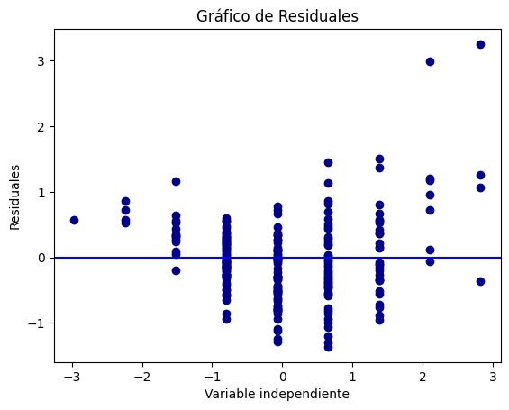

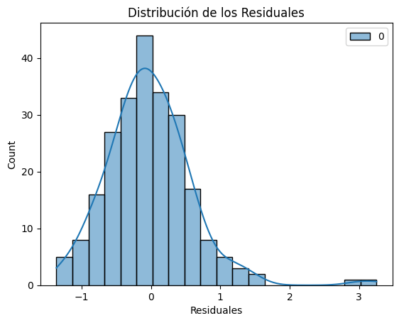

```python
#Analizando residuales
residuos = ytest - y_pred
print("Los residuos son: ", len(residuos))

plt.plot(xtest, residuos, 'o', color='darkblue')
plt.axhline(0,color='blue')
plt.title("Gráfico de Residuales")
plt.xlabel("Variable independiente")
plt.ylabel("Residuales")
plt.show()

sns.histplot(residuos, kde=True)  # kde=True para incluir la curva de densidad
plt.xlabel("Residuales")
plt.title("Distribución de los Residuales")
plt.show()
```

## 12. Modelo multivariado de regresión lineal para predecir el precio de las casas

Para este modelo utilizamos todas las variables numericas para predecir el precio de las casas

```
Variables utilizadas en el modelo: ['Id', 'MSSubClass', 'MSZoning', 'LotFrontage', 'LotArea', 'Street', 'LotShape', 'LandContour', 'Utilities', 'LotConfig', 'LandSlope', 'Neighborhood', 'Condition1', 'Condition2', 'BldgType', 'HouseStyle', 'OverallQual', 'OverallCond', 'YearBuilt', 'YearRemodAdd', '…
Mean Squared Error: 0.16
R squared: 0.87
                            OLS Regression Results
==============================================================================
Dep. Variable:              SalePrice   R-squared:                       0.911
Model:                            OLS   Adj. R-squared:                  0.904
Method:                 Least Squares   F-statistic:                     123.1
Date:                Sun, 02 Mar 2025   Prob (F-statistic):               0.00
Time:                        21:22:39   Log-Likelihood:                -215.59
No. Observations:                 934   AIC:                             577.2
Df Residuals:                     861   BIC:                             930.5
Df Model:                          72
Covariance Type:            nonrobust
=================================================================================
                    coef    std err          t      P>|t|      [0.025      0.975]
---------------------------------------------------------------------------------
const            -0.0425      0.287     -0.148      0.882      -0.606       0.521
Id               -0.0051      0.011     -0.467      0.641      -0.026       0.016
MSSubClass       -0.0120      0.025     -0.488      0.626      -0.060       0.036
MSZoning         -0.0231      0.021     -1.118      0.264      -0.064       0.017
LotFrontage       0.0356      0.015      2.314      0.021       0.005       0.066
LotArea           0.0662      0.012      5.358      0.000       0.042       0.090
Street            0.3963      0.174      2.283      0.023       0.056       0.737
LotShape         -0.0086      0.008     -1.036      0.300      -0.025       0.008
LandContour      -0.0047      0.017     -0.274      0.784      -0.038       0.029
Utilities     -4.172e-16   2.01e-16     -2.071      0.039   -8.13e-16   -2.17e-17
LotConfig        -0.0085      0.007     -1.220      0.223      -0.022       0.005
LandSlope        -0.0506      0.046     -1.104      0.270      -0.141       0.039
Neighborhood      0.0007      0.002      0.358      0.721      -0.003       0.005
Condition1       -0.0107      0.013     -0.812      0.417      -0.037       0.015
Condition2       -0.0103      0.037     -0.282      0.778      -0.082       0.062
BldgType         -0.0334      0.019     -1.781      0.075      -0.070       0.003
HouseStyle       -0.0016      0.008     -0.199      0.842      -0.018       0.015
OverallQual       0.1354      0.021      6.590      0.000       0.095       0.176
OverallCond       0.0540      0.014      3.772      0.000       0.026       0.082
YearBuilt         0.1034      0.030      3.428      0.001       0.044       0.163
YearRemodAdd      0.0323      0.017      1.849      0.065      -0.002       0.067
RoofStyle         0.0139      0.015      0.947      0.344      -0.015       0.043
RoofMatl          0.0173      0.019      0.891      0.373      -0.021       0.056
```

[output cut: 49 more lines]

```
MoSold           -0.0164      0.011     -1.483      0.138      -0.038       0.005
YrSold           -0.0109      0.011     -0.992      0.322      -0.032       0.011
SaleType         -0.0025      0.007     -0.348      0.728      -0.017       0.012
SaleCondition     0.0322      0.011      2.997      0.003       0.011       0.053
==============================================================================
Omnibus:                      273.746   Durbin-Watson:                   2.056
Prob(Omnibus):                  0.000   Jarque-Bera (JB):             2450.498
Skew:                           1.071   Prob(JB):                         0.00
Kurtosis:                      10.640   Cond. No.                     1.01e+16
==============================================================================

Notes:
[1] Standard Errors assume that the covariance matrix of the errors is correctly specified.
[2] The smallest eigenvalue is 5.97e-27. This might indicate that there are
strong multicollinearity problems or that the design matrix is singular.
```

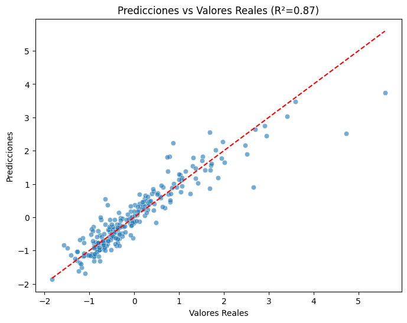

```python
# Seleccionar solo las variables numéricas
numerical_features = train_df.select_dtypes(include=['number']).columns
numerical_features = numerical_features.drop("SalePrice")  # Excluir la variable objetivo
print("Variables utilizadas en el modelo:", numerical_features.tolist())


# Definir variables predictoras (X) y variable objetivo (y)
X = train_df[numerical_features]
y = train_df["SalePrice"]

# Dividir los datos en conjunto de entrenamiento (80%) y prueba (20%)
X_train, X_test, y_train, y_test = train_test_split(X, y, test_size=0.2, random_state=42)

# Crear el modelo de regresión lineal
lm = LinearRegression()
lm.fit(X_train, y_train)

# Hacer predicciones en el conjunto de prueba
y_pred = lm.predict(X_test)

# Calcular métricas del modelo
r2 = r2_score(y_test, y_pred)
mse = mean_squared_error(y_test, y_pred)

print(f"Mean Squared Error: {mse:.2f}")
print(f"R squared: {r2:.2f}")

# Análisis del modelo con statsmodels
X_train_sm = sm.add_constant(X_train)  # Agregar constante para la regresión
model_sm = sm.OLS(y_train, X_train_sm).fit()
print(model_sm.summary())

# Gráfico de predicciones vs valores reales
plt.figure(figsize=(8, 6))
sns.scatterplot(x=y_test, y=y_pred, alpha=0.6)
plt.plot([min(y_test), max(y_test)], [min(y_test), max(y_test)], color="red", linestyle="--")  # Línea de referencia
plt.xlabel("Valores Reales")
plt.ylabel("Predicciones")
plt.title(f"Predicciones vs Valores Reales (R²={r2:.2f})")
plt.show()
```

En la regresión lineal que se obtuvo con todas las variables numéricas, presenta un coeficiente de determinación R cuadrado de 0.87 que indica que el 87% de la variabilidad en el precio de las casas se explica por las variables numéricas. Se puede observar que los puntos están cerca de la línea roja, lo que indica que el modelo está funcionando bien.

## 12.1 Residuos

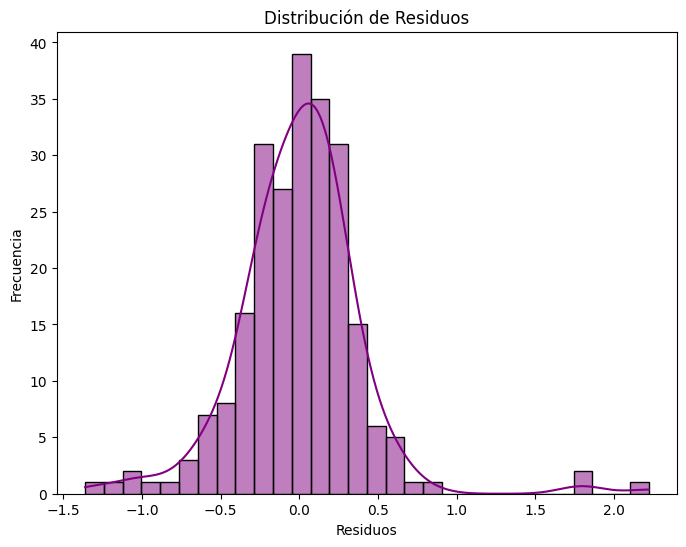

```python
# Analizando los residuos
residuos = y_test - y_pred

# Gráfico de distribución de residuos
plt.figure(figsize=(8, 6))
sns.histplot(residuos, bins=30, kde=True, color="purple")
plt.xlabel("Residuos")
plt.ylabel("Frecuencia")
plt.title("Distribución de Residuos")
plt.show()
```

### 13. Análisis de multicolinealidad, correlación y detección de sobreajuste

En este paso, se analizan las posibles correlaciones entre las variables predictoras y se determina si existe multicolinealidad. También se revisa el ajuste del modelo para identificar si está ocurriendo un sobreajuste (overfitting).

**Pasos principales**:

1. Calcular la matriz de correlación para las variables numéricas y observar las variables más correlacionadas entre sí y con la variable respuesta (SalePrice).
2. Calcular el Factor de Inflación de Varianza (VIF) para detectar multicolinealidad.
3. Entrenar un modelo de Regresión Lineal Múltiple con todas las variables numéricas seleccionadas (en pasos previos).
4. Analizar la puntuación R² en entrenamiento y en validación (o prueba) para evidenciar posible sobreajuste.

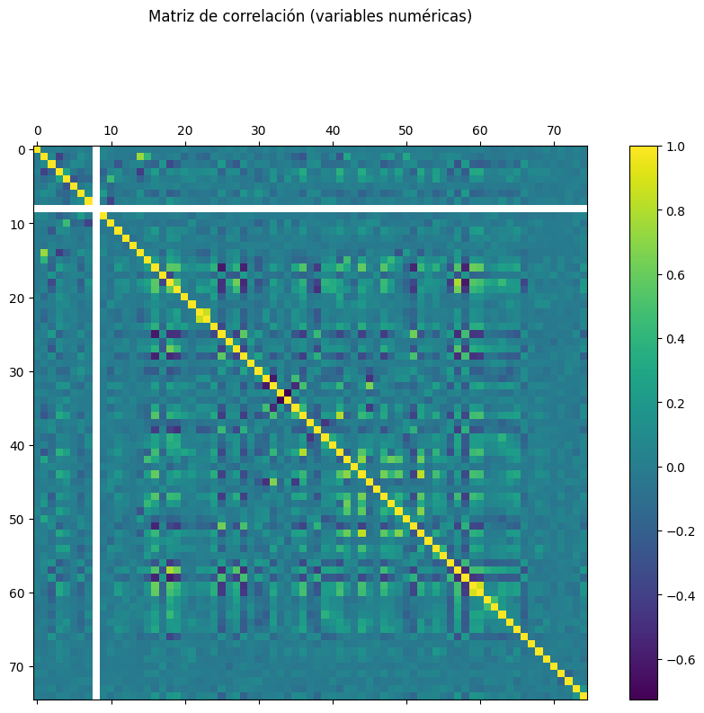

```
VIF de las variables (orden descendente):
Utilities: nan
BsmtFinSF1: inf
BsmtFinSF2: inf
BsmtUnfSF: inf
TotalBsmtSF: inf
1stFlrSF: inf
2ndFlrSF: inf
LowQualFinSF: inf
GrLivArea: inf
YearBuilt: 8.22
GarageCars: 6.77
GarageArea: 6.53
MSSubClass: 5.37
TotRmsAbvGrd: 5.17
BldgType: 4.40
Exterior1st: 4.07
Exterior2nd: 4.00
GarageYrBlt: 3.91
OverallQual: 3.84
FullBath: 3.48
YearRemodAdd: 2.81
BedroomAbvGr: 2.77
BsmtFullBath: 2.67
ExterQual: 2.62
HalfBath: 2.47
BsmtFinType2: 2.38
HouseStyle: 2.34
BsmtQual: 2.24
GarageFinish: 2.16
Foundation: 2.09
KitchenQual: 2.08
BsmtFinType1: 2.05
Fireplaces: 1.94
OverallCond: 1.93
KitchenAbvGr: 1.83
LotFrontage: 1.82
CentralAir: 1.82
GarageType: 1.79
LotArea: 1.72
```

[output cut: 25 more lines]

```
SaleCondition: 1.18
SaleType: 1.17
BsmtCond: 1.16
Condition1: 1.14
YrSold: 1.13
MoSold: 1.11
PoolArea: 1.11
Condition2: 1.10
Id: 1.08
3SsnPorch: 1.07
MiscVal: 1.06
R2 (Train) con todas las variables: 0.9114577089724687
RMSE (Train) con todas las variables: 0.3047950156392137
R2 (Test) con todas las variables: 0.8656974161878999
RMSE (Test) con todas las variables: 0.3959902743662094
```

```python
# 1. Matriz de correlación (variables numéricas)
# Asegurar de seleccionar solo columnas numéricas
numeric_features = X_train.select_dtypes(include=[np.number])
corr_matrix = numeric_features.corr()

plt.figure(figsize=(12, 8))
plt.matshow(corr_matrix, fignum=0)
plt.title("Matriz de correlación (variables numéricas)", pad=100)
plt.colorbar()
plt.show()

# 2. Función para calcular el VIF de cada variable
def calcular_vif(df):
    """
    Calcula el VIF de cada columna en un DataFrame.
    VIF = 1 / (1 - R^2)
    """
    vif_data = []
    # Se añade la constante para usar en el modelo
    df_const = sm.add_constant(df)

    for i, col in enumerate(df.columns):
        # Se elimina la columna 'col' para ver su VIF
        X_temp = df_const.drop(columns=[col], errors='ignore')
        y_temp = df_const[col]

        model = sm.OLS(y_temp, X_temp)
        results = model.fit()

        r2 = results.rsquared
        vif = np.inf if r2 == 1 else 1/(1 - r2)

        vif_data.append((col, vif))

    # Ordenamos de mayor a menor VIF
    vif_data.sort(key=lambda x: x[1], reverse=True)
    return vif_data

# Calculamos el VIF ignorando la variable 'SalePrice' si estuviera en numeric_features
vif_resultados = calcular_vif(numeric_features.drop(columns=['SalePrice'], errors='ignore'))
print("VIF de las variables (orden descendente):")
for var, val in vif_resultados:
    print(f"{var}: {val:.2f}")

# 3. Entrenar el modelo de Regresión Lineal con TODAS las variables numéricas
linreg_all = LinearRegression()
linreg_all.fit(X_train, y_train)

# 4. Métricas en el conjunto de entrenamiento para ver si hay sobreajuste
y_pred_train = linreg_all.predict(X_train)
r2_train = r2_score(y_train, y_pred_train)

#  mean_squared_error sin el parámetro 'squared'
mse_train = mean_squared_error(y_train, y_pred_train)
rmse_train = np.sqrt(mse_train)

print("R2 (Train) con todas las variables:", r2_train)
print("RMSE (Train) con todas las variables:", rmse_train)

# Métricas en el conjunto de prueba
y_pred_test = linreg_all.predict(X_test)
r2_test = r2_score(y_test, y_pred_test)

mse_test = mean_squared_error(y_test, y_pred_test)
rmse_test = np.sqrt(mse_test)

print("R2 (Test) con todas las variables:", r2_test)
print("RMSE (Test) con todas las variables:", rmse_test)
```

- **TotalBsmtSF** ya resume la información de `BsmtFinSF1`, `BsmtFinSF2` y `BsmtUnfSF`.
- **GrLivArea** agrupa el área habitable de 1er y 2do piso, además de `LowQualFinSF`.
- **GarageCars** y **GarageArea** miden casi lo mismo; conviene elegir la que mejor se correlacione con **SalePrice**.
- **Utilities** suele no variar o aportar mucho, por lo que suele eliminarse.
- **YearBuilt** puede resultar prescindible si **YearRemodAdd** está muy correlacionado y refleja mejor la actualización de la casa.

### 14. Nuevo modelo (reducción de variables o regularización) y análisis de residuos

Si se detecta multicolinealidad (VIF alto en algunas variables) o signos de sobreajuste (alta diferencia de desempeño entre entrenamiento y prueba), podemos:

- Eliminar variables con VIF muy alto para reducir multicolinealidad.
- Emplear modelos de regularización (por ejemplo, Lasso o Ridge).
- Seleccionar solo las variables más predictivas según análisis de correlación o importancia del modelo.

Luego de ajustar el nuevo modelo, se analizan los residuos para verificar la calidad del ajuste (normalidad de residuos, homocedasticidad, etc.). Se suelen graficar:

- Gráfico de valores predichos vs. residuos.
- Histograma o Q-Q plot de residuos para ver su distribución.

```
R2 (Train) [Ridge]: 0.9018920049655823
MSE (Train) [Ridge]: 0.1029364926729259
RMSE (Train) [Ridge]: 0.32083717470537276
```

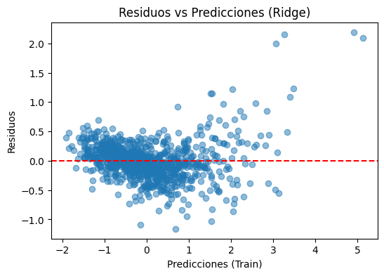

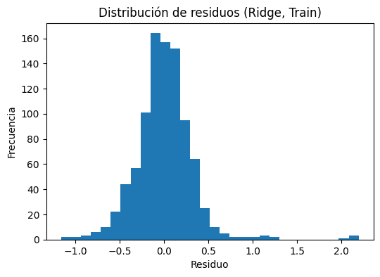

```python
# ===============================
# Regularización con Ridge
# ===============================
import numpy as np
import matplotlib.pyplot as plt
from sklearn.linear_model import Ridge
from sklearn.metrics import mean_squared_error, r2_score

# Variables a eliminar (según análisis de VIF y correlaciones)
vars_a_eliminar = [
    "BsmtFinSF1", "BsmtFinSF2", "BsmtUnfSF",  # ya se resume en TotalBsmtSF
    "1stFlrSF", "2ndFlrSF", "LowQualFinSF",   # ya se incluye en GrLivArea
    "GarageArea",                             # muy correlacionada con GarageCars
    "Utilities",                              # poca variación / utilidad
    "YearBuilt"                               # fuertemente correlacionada con YearRemodAdd
]

# Reducción de columnas en train y test
X_train_reduced = X_train.drop(columns=vars_a_eliminar, errors='ignore')
X_test_reduced = X_test.drop(columns=vars_a_eliminar, errors='ignore')

# Entrenar el modelo con Ridge (penalización alpha=10.0)
ridge_model = Ridge(alpha=10.0)
ridge_model.fit(X_train_reduced, y_train)

# Predicciones en el set de entrenamiento
y_train_pred_ridge = ridge_model.predict(X_train_reduced)
residuos_train = y_train - y_train_pred_ridge

# Cálculo de métricas en entrenamiento
r2_train_ridge = r2_score(y_train, y_train_pred_ridge)
mse_train_ridge = mean_squared_error(y_train, y_train_pred_ridge)
rmse_train_ridge = np.sqrt(mse_train_ridge)

print("R2 (Train) [Ridge]:", r2_train_ridge)
print("MSE (Train) [Ridge]:", mse_train_ridge)
print("RMSE (Train) [Ridge]:", rmse_train_ridge)

# ==============
# Análisis de residuos
# ==============
# Gráfica de residuos vs. predicciones
plt.figure(figsize=(6,4))
plt.scatter(y_train_pred_ridge, residuos_train, alpha=0.5)
plt.axhline(y=0, color='r', linestyle='--')
plt.title("Residuos vs Predicciones (Ridge)")
plt.xlabel("Predicciones (Train)")
plt.ylabel("Residuos")
plt.show()

# Histograma de residuos para ver su distribución
plt.figure(figsize=(6,4))
plt.hist(residuos_train, bins=30)
plt.title("Distribución de residuos (Ridge, Train)")
plt.xlabel("Residuo")
plt.ylabel("Frecuencia")
plt.show()
```

### 15. Uso de cada modelo con el conjunto de prueba y eficiencia en la predicción

En este punto, utilizamos los modelos entrenados (por ejemplo, el modelo de Regresión Lineal con todas las variables y el modelo de Ridge regularizado con variables reducidas) para predecir en el conjunto de prueba. Luego comparamos las métricas (R², RMSE, etc.) para determinar la calidad de las predicciones de cada modelo. Haciendo uso de métricas como:

- R² (Coeficiente de Determinación)
- RMSE (Raíz del Error Cuadrático Medio)
- MAE (Error Absoluto Medio), etc.

Se comparan los resultados para determinar cuál modelo realiza mejores predicciones.

```python
# Evaluación del modelo original (linreg_all) en Test
y_pred_test_all = linreg_all.predict(X_test)
r2_test_all = r2_score(y_test, y_pred_test_all)
mse_test_all = mean_squared_error(y_test, y_pred_test_all)
rmse_test_all = np.sqrt(mse_test_all)

print("=== Modelo Original (todas las variables) ===")
print("R2 (Test):", r2_test_all)
print("MSE (Test):", mse_test_all)
print("RMSE (Test):", rmse_test_all)
print()

# Evaluación del modelo Ridge (vars reducidas) en Test
y_pred_test_ridge = ridge_model.predict(X_test_reduced)
r2_test_ridge = r2_score(y_test, y_pred_test_ridge)
mse_test_ridge = mean_squared_error(y_test, y_pred_test_ridge)
rmse_test_ridge = np.sqrt(mse_test_ridge)

print("=== Modelo Ridge (variables reducidas) ===")
print("R2 (Test):", r2_test_ridge)
print("MSE (Test):", mse_test_ridge)
print("RMSE (Test):", rmse_test_ridge)
```

```
=== Modelo Original (todas las variables) ===
R2 (Test): 0.8656974161878999
MSE (Test): 0.15680829739262583
RMSE (Test): 0.3959902743662094

=== Modelo Ridge (variables reducidas) ===
R2 (Test): 0.8667792695374293
MSE (Test): 0.15554515280558212
RMSE (Test): 0.3943921307602145
```

# Proyecto 2 “House Prices: Advanced Regression Techniques” - Parte 2 Arbole de decisión

## 1. Uso de los mismos conjuntos de entrenamiento y prueb

```python
# ===========================================
# 1. Carga de datos y separación en train/test
# ===========================================
import pandas as pd
from sklearn.model_selection import train_test_split
from sklearn.metrics import accuracy_score, confusion_matrix, classification_report
from sklearn.model_selection import train_test_split, cross_val_score
from sklearn.tree import DecisionTreeClassifier
from sklearn.model_selection import cross_val_score

# Cargamos los datos
train_df = pd.read_csv("train_preprocessed.csv")
# test_df = pd.read_csv("test_preprocessed.csv")

# Con variable objetivo es 'SalePrice'
X = train_df.drop(["SalePrice"], axis=1)
y = train_df["SalePrice"]

# mantener la misma proporción y la misma semilla (random_state) que en la entrega anterior
X_train, X_test, y_train, y_test = train_test_split(X, y,
                                                    test_size=0.2,
                                                    random_state=42)

print("Tamaño de X_train:", X_train.shape)
print("Tamaño de X_test: ", X_test.shape)
```

```
Tamaño de X_train: (934, 75)
Tamaño de X_test:  (234, 75)
```

# 2. Elaborar un árbol de regresión con todas las variables

Entrenamos un modelo de árbol de decisión para **regresión** utilizando todas las variables predictoras. Luego veremos qué tan bien se ajusta a los datos.

```python
# ===========================================
# 2. Árbol de Regresión (modelo base)
# ===========================================
from sklearn.tree import DecisionTreeRegressor

# Creamos el modelo con una configuración básica (sin limitar la profundidad)
reg_tree = DecisionTreeRegressor(random_state=42)
reg_tree.fit(X_train, y_train)

print("Árbol de regresión entrenado con éxito.")
```

```
Árbol de regresión entrenado con éxito.
```

# 3. Usar el modelo para predecir y analizar el resultado

Se evalúa el modelo realizando predicciones sobre el conjunto de prueba y calculando métricas de error como MSE y RMSE, así como el R² (coeficiente de determinación).

```python
# ===========================================
# 3. Predicción y evaluación del árbol de regresión
# ===========================================
from sklearn.metrics import mean_squared_error, r2_score

# Realizamos la predicción sobre el set de prueba
y_pred = reg_tree.predict(X_test)

# Cálculo de métricas
mse = mean_squared_error(y_test, y_pred)
rmse = mse ** 0.5
r2 = r2_score(y_test, y_pred)

print("MSE:", mse)
print("RMSE:", rmse)
print("R2:", r2)
```

```
MSE: 0.269173752305001
RMSE: 0.5188195758691079
R2: 0.7694590718089135
```

# 4. Crear al menos 3 modelos más variando la profundidad del árbol

Probaremos diferentes valores para el parámetro de profundidad (`max_depth`) y compararemos los resultados en términos de MSE, RMSE y R².

```python
# ===========================================
# 4. Probando diferentes profundidades del árbol
# ===========================================
import numpy as np

depths = [2, 5, 10]  # Diferentes profundidades de ejemplo

for d in depths:
    reg_tree_temp = DecisionTreeRegressor(max_depth=d, random_state=42)
    reg_tree_temp.fit(X_train, y_train)
    y_pred_temp = reg_tree_temp.predict(X_test)

    mse_temp = mean_squared_error(y_test, y_pred_temp)
    rmse_temp = mse_temp ** 0.5
    r2_temp = r2_score(y_test, y_pred_temp)

    print(f"Profundidad: {d}")
    print(f" -> MSE: {mse_temp:.2f}")
    print(f" -> RMSE: {rmse_temp:.2f}")
    print(f" -> R2: {r2_temp:.4f}")
    print("-"*30)
```

```
Profundidad: 2
 -> MSE: 0.42
 -> RMSE: 0.65
 -> R2: 0.6387
------------------------------
Profundidad: 5
 -> MSE: 0.22
 -> RMSE: 0.47
 -> R2: 0.8090
------------------------------
Profundidad: 10
 -> MSE: 0.29
 -> RMSE: 0.54
 -> R2: 0.7494
------------------------------
```

# 5. Comparación con el modelo de regresión lineal de la entrega anterior

Error cuadrático medio (MSE):

- Árbol de regresión: 0.2692
- Regresión lineal (original): 0.1568
- Regresión con Ridge: 0.1555

Raíz del error cuadrático medio (RMSE):

- Árbol de regresión: 0.5188
- Regresión lineal (original): 0.3960
- Regresión con Ridge: 0.3944

Coeficiente de determinación (R²):

- Árbol de regresión: 0.7695
- Regresión lineal (original): 0.8657
- Regresión con Ridge: 0.8668

Según los resultados, se puede observar que en ambas versiones de la regresión lineal existe un MSE menor, lo que indica que sus predicciones son más precisas en promedio. Asimismo, el RMSE también es menor en la regresión lineal lo que confirma que los errores individuales tienden a ser menores en comparación con el árbol de regresión. También la regresión lineal explica mejor la variabilidad de los datos ya que vemos un coeficiente de determinación más cercano a uno en la regresión lineal. Por lo tanto, se puede concluir que, para este caso, la regresión lineal es un mejor modelo.

# 6. Creación de la variable de clasificación (Económicas, Intermedias, Caras)

Definimos una nueva variable categórica (por ejemplo, usando cuantiles) a partir del precio de la vivienda (SalePrice). Luego, esa variable será la nueva `y` para un árbol de clasificación.

```python
# ===========================================
# 6. Creando variable categórica de 3 clases
# ===========================================
import numpy as np

# Calculamos dos cuantiles para dividir en 3 grupos (Económicas, Intermedias, Caras)
q1 = train_df["SalePrice"].quantile(0.33)
q2 = train_df["SalePrice"].quantile(0.66)

def categorizar_precio(precio):
    if precio <= q1:
        return "Económica"
    elif precio <= q2:
        return "Intermedia"
    else:
        return "Cara"

# Creamos la nueva columna en el DataFrame
train_df["PrecioCat"] = train_df["SalePrice"].apply(categorizar_precio)

# Observamos la distribución de las categorías
print(train_df["PrecioCat"].value_counts())
```

```
PrecioCat
Cara          397
Económica     391
Intermedia    380
Name: count, dtype: int64
```

# 7. Árbol de clasificación utilizando la nueva variable de 3 clases

Ahora creamos un árbol de decisión para clasificación, usando `PrecioCat` como variable objetivo y excluyendo `SalePrice` del conjunto de predictores. Mostramos gráficamente el árbol y su profundidad.

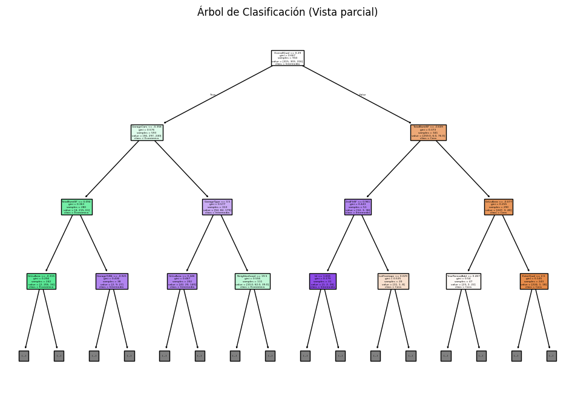

```
Profundidad total del árbol de clasificación: 14
Nodos (hojas) en el árbol de clasificación: 120
¡La imagen se ha guardado en 'img/arbol_clasificacion.png'!
```

```python
# ===========================================
# 7. Entrenamiento del árbol de clasificación
# ===========================================
import os
import matplotlib.pyplot as plt
from sklearn.tree import DecisionTreeClassifier, plot_tree
from sklearn.model_selection import train_test_split

# Verificar si la carpeta 'img' existe; si no, crearla
if not os.path.exists("img"):
    os.makedirs("img")

# X_clf: todas las columnas excepto SalePrice y la nueva variable PrecioCat
X_clf = train_df.drop(["SalePrice", "PrecioCat"], axis=1)

# y_clf: la variable categórica
y_clf = train_df["PrecioCat"]

# Dividimos en train y test
X_train_clf, X_test_clf, y_train_clf, y_test_clf = train_test_split(
    X_clf, y_clf, test_size=0.2, random_state=42
)

# Creamos el árbol de clasificación
clf_tree = DecisionTreeClassifier(random_state=42)
clf_tree.fit(X_train_clf, y_train_clf)

# Visualización del árbol (versión resumida, máximo 3 niveles)
plt.figure(figsize=(12, 8))
plot_tree(
    clf_tree,
    feature_names=X_clf.columns,
    class_names=clf_tree.classes_,
    filled=True,
    max_depth=3
)
plt.title("Árbol de Clasificación (Vista parcial)")

# Guardar la figura como PNG en la carpeta 'img'
plt.savefig("img/arbol_clasificacion.png", dpi=300, bbox_inches='tight')
plt.show()

# Información sobre la complejidad del árbol
print("Profundidad total del árbol de clasificación:", clf_tree.get_depth())
print("Nodos (hojas) en el árbol de clasificación:", clf_tree.get_n_leaves())
print("¡La imagen se ha guardado en 'img/arbol_clasificacion.png'!")
```

# 8. Eficiencia del Árbol de clasificación

Utilizamos el modelo con el conjunto de prueba y determinamos la eficiencia del algoritmo para clasificar.

```python
# ===============================
# Evaluación del modelo
# ===============================

# Predicciones en el conjunto de prueba
y_pred_clf = clf_tree.predict(X_test_clf)

# Calcular precisión
accuracy = accuracy_score(y_test_clf, y_pred_clf)
print(f"Precisión del modelo: {accuracy:.4f}")
```

Precisión del modelo: 0.7265

Los resultados indican que el modelo tiene una precisión de 0.7265, lo que significa que el modelo clasifica correctamente el 72.65% de las instancias en el conjunto de prueba. Tiene un 72.65% de precisión.

# 9. Matriz de confusión

Analizamos la eficiencia del algoritmo usando una matriz de confusión para el árbol de clasificación.

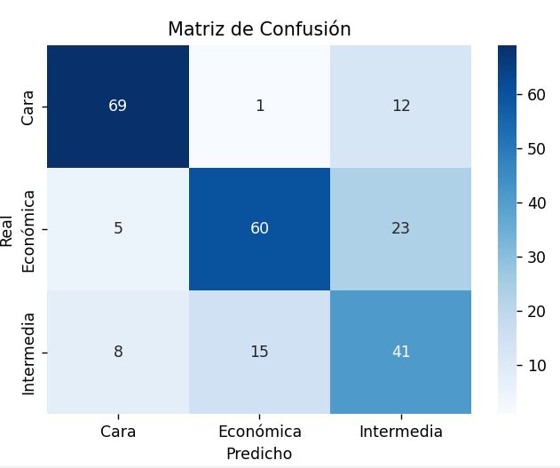

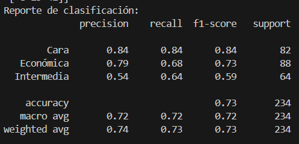

```python
# Mostrar matriz de confusión
conf_matrix = confusion_matrix(y_test_clf, y_pred_clf)
print("Matriz de confusión:")
print(conf_matrix)

# Mostrar reporte de clasificación
class_report = classification_report(y_test_clf, y_pred_clf)
print("Reporte de clasificación:")
print(class_report)

# Visualización de la matriz de confusión
plt.figure(figsize=(6, 4))
sns.heatmap(conf_matrix, annot=True, fmt='d', cmap='Blues', xticklabels=clf_tree.classes_, yticklabels=clf_tree.classes_)
plt.xlabel("Predicho")
plt.ylabel("Real")
plt.title("Matriz de Confusión")
plt.show()
```

Según los datos que muestra la matriz de confusión y su reporte de clasificación, clasificó correctamente la categoría de precio para casas caras con un valor de 69 aciertos, asimismo para la categoría económica con 60 aciertos y la intermedia con 41, teniendo un total de 170 aciertos. Por otro lado, presenta 64 casos mal clasificados.

Errores más comunes:

- Clasificar "Económica" → "Intermedia": 23 veces
- Clasificar "Intermedia" → "Económica": 15 veces
- Clasificar "Intermedia" → "Cara": 8 veces
- Clasificar "Cara" → "Intermedia": 12 veces

Existe un tipo de confusión entre las variables económica e intermedia lo que puede significar que la diferencia entre estas dos no está siendo bien capturada por el modelo. La clase cara es la mejor identificada pero se confunde con intermedia en 12 casos lo que indica que algunas de las casas caras tienen caracteristicas similares a las de clase intermedia.

El modelo es mejor para clasificar casas de clase cara y económica, no tanto para intermedias.

Importancia de los errores: Radica en que, si una casa cara es clasificada como intermedia, significa una pérdida para el vendedor porque puede estarse vendiendo por debajo de su valor verdadero, este es el error más grave y debe minimizarse. También si una casa económica es clasificada como intermedia o cara puede generar problemas entre el vendedor y el comprador, ya que el comprador estaría pagando más de lo que vale u ofrece la casa, lo que llevaría a reclamos y en el peor de los casos, pérdida para el vendedor.

# 10. Modelo con validación cruzada

Entrenamos un modelo con validación cruzada y comparamos con el modelo anterior.

```python
# Dividimos en train y test
X_train_clf, X_test_clf, y_train_clf, y_test_clf = train_test_split(
    X_clf, y_clf, test_size=0.2, random_state=42
)

# Creamos el árbol de clasificación
clf_tree = DecisionTreeClassifier(random_state=42)
clf_tree.fit(X_train_clf, y_train_clf)

# Validación cruzada
cv_scores = cross_val_score(clf_tree, X_clf, y_clf, cv=5, scoring='accuracy')

# Mostrar resultados de la validación cruzada
print(f"Precisión promedio de validación cruzada: {cv_scores.mean():.4f}")
print(f"Desviación estándar de la validación cruzada: {cv_scores.std():.4f}")
```

- Precisión promedio de validación cruzada: 0.7414
- Desviación estándar de la validación cruzada: 0.0119

# 11. Tres modelos más cambiando la profundidad

Realizamos 3 modelos más, cambiando la profundidad del árbol y determinamos cuál funcionó mejor

```python
# Definir diferentes profundidades para los árboles
depths = [3, 5, 7]

# Crear y evaluar modelos con diferentes profundidades
for depth in depths:
    # Crear el árbol con la profundidad especificada
    clf_tree = DecisionTreeClassifier(max_depth=depth, random_state=42)

    # Realizar validación cruzada y obtener las precisiones
    cv_scores = cross_val_score(clf_tree, X_clf, y_clf, cv=5, scoring='accuracy')

    # Mostrar resultados
    print(f"Modelo con profundidad {depth}:")
    print(f"  - Precisión promedio de validación cruzada: {cv_scores.mean():.4f}")
    print(f"  - Desviación estándar: {cv_scores.std():.4f}")
    print("-" * 50)
```

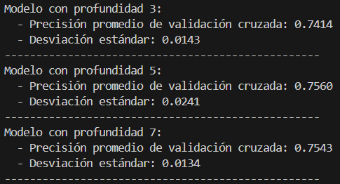

Se puede notar que el modelo con profundidad 5 es el que tiene mejor precisión con un valor de 0.7560 o 75.60%. A continuación, con el conjunto de prueba realizaremos una matriz de confusión para visualizar mejor los resultados del modelo final con profundidad que tiene mayor precisión:

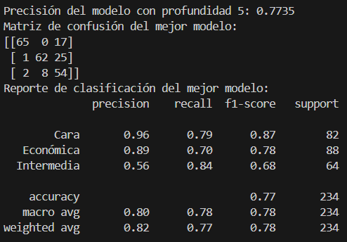

```python
# ===============================
# Evaluación final del modelo (con validación cruzada)
# ===============================
# El modelo final con la mejor profundidad se entrenará y evaluará aquí
best_depth = 5
clf_tree_best = DecisionTreeClassifier(max_depth=best_depth, random_state=42)
clf_tree_best.fit(X_train_clf, y_train_clf)

# Predicciones y evaluación
y_pred_clf_best = clf_tree_best.predict(X_test_clf)
accuracy_best = accuracy_score(y_test_clf, y_pred_clf_best)
print(f"Precisión del modelo con profundidad {best_depth}: {accuracy_best:.4f}")

# Mostrar matriz de confusión
conf_matrix_best = confusion_matrix(y_test_clf, y_pred_clf_best)
print("Matriz de confusión del mejor modelo:")
print(conf_matrix_best)

# Mostrar reporte de clasificación
class_report_best = classification_report(y_test_clf, y_pred_clf_best)
print("Reporte de clasificación del mejor modelo:")
print(class_report_best)

# Visualización de la matriz de confusión
plt.figure(figsize=(6, 4))
sns.heatmap(conf_matrix_best, annot=True, fmt='d', cmap='Blues', xticklabels=clf_tree_best.classes_, yticklabels=clf_tree_best.classes_)
plt.xlabel("Predicho")
plt.ylabel("Real")
plt.title(f"Matriz de Confusión del Árbol con Profundidad {best_depth}")
plt.show()
```

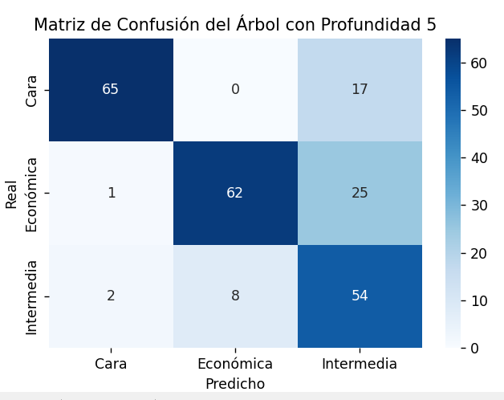

Según los resultados, el modelo con profundidad 5 es el que tiene una mejor precisión al momento de clasificar una casa entre las categorías "Cara", "intermedia" y "económica". En la matriz de confusión se puede observar una mejoría en la clasificación de las casas, ya que ahora hay 65 aciertos en la clase cara, 62 en económica y 54 en intermedia, para un total de 181 aciertos. Mejorar la profundidad contribuyó a obtener un mejor rendimiento del modelo.

# 12. Análisis utilizando Random Forest

Para comparar con el árbol de decisión, entrenamos ahora un modelo de **Random Forest** (ensamble de múltiples árboles). Revisamos métricas de exactitud, matriz de confusión y observamos si mejora con respecto al árbol de decisión simple

```
Exactitud (accuracy) de Random Forest en test: 0.8290598290598291
Matriz de Confusión - Random Forest:
[[73  0  9]
 [ 2 76 10]
 [ 3 16 45]]
```

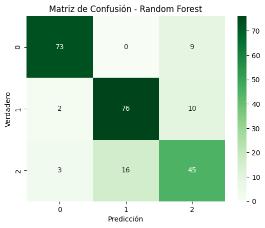

```
Reporte de Clasificación - Random Forest:
              precision    recall  f1-score   support

        Cara       0.94      0.89      0.91        82
   Económica       0.83      0.86      0.84        88
  Intermedia       0.70      0.70      0.70        64

    accuracy                           0.83       234
   macro avg       0.82      0.82      0.82       234
weighted avg       0.83      0.83      0.83       234
```

```python
# ===========================================
# 12. Random Forest para clasificación (corregido)
# ===========================================
from sklearn.ensemble import RandomForestClassifier
from sklearn.metrics import accuracy_score, confusion_matrix, classification_report

# Entrenamos un RandomForestClassifier
rf_clf = RandomForestClassifier(n_estimators=100, random_state=42)
rf_clf.fit(X_train_clf, y_train_clf)

# Predicción sobre el test
y_pred_rf = rf_clf.predict(X_test_clf)

# Exactitud del Random Forest
accuracy_rf = accuracy_score(y_test_clf, y_pred_rf)
print("Exactitud (accuracy) de Random Forest en test:", accuracy_rf)

# Matriz de confusión para Random Forest
cm_rf = confusion_matrix(y_test_clf, y_pred_rf)
print("Matriz de Confusión - Random Forest:")
print(cm_rf)

# Visualización de la matriz
import seaborn as sns
sns.heatmap(cm_rf, annot=True, fmt='d', cmap='Greens')
plt.title("Matriz de Confusión - Random Forest")
plt.xlabel("Predicción")
plt.ylabel("Verdadero")
plt.show()

# Reporte de clasificación
report_rf = classification_report(y_test_clf, y_pred_rf)
print("Reporte de Clasificación - Random Forest:")
print(report_rf)
```

En el reporte de clasificación, destaca la precisión (precision) de la clase Cara (0.94) y la exhaustividad (recall) de la clase Económica (0.86). La categoría Intermedia, en cambio, presenta valores más bajos (0.70 de precisión y 0.70 de recall), confirmando que el modelo tiende a confundir las casas Intermedias con las de mayor o menor precio. Aun así, se logra un f1-score global de 0.83 y un promedio macro de 0.82, indicando un buen desempeño en las tres clases.

En conjunto, estos resultados evidencian que el Random Forest mejora la clasificación respecto a un solo árbol de decisión, pues combina múltiples árboles y, por ende, reduce la varianza y mejora la robustez del modelo. Sin embargo, aún es posible observar ciertos errores en la diferenciación de las categorías Intermedias, un patrón que podría abordarse mediante un mejor ajuste de hiperparámetros (como n_estimators o la profundidad máxima de los árboles en el bosque) o incluyendo variables adicionales que ayuden al modelo a discernir mejor entre las clases.